# PRÁCTICA 4

## Ejercicio 1

## a)

```r
library(PASWR2)
str(STATTEMPS)
```

```
## 'data.frame':    34 obs. of  3 variables:
##  $ temperature: num  92.7 94.1 96.5 93.2 97.1 93.7 94.1 96 98.2 96.5 ...
##  $ gender     : Factor w/ 2 levels "Female","Male": 2 2 2 2 2 2 2 2 2 2 ...
##  $ class      : Factor w/ 2 levels "8 a.m.","9 a.m.": 1 1 1 1 1 1 2 2 2 2 ...
```

[figure not shown]

[output not shown]

[output not shown]

```r
men<-STATTEMPS$temperature[STATTEMPS$gender=="Male"]
women<-STATTEMPS$temperature[STATTEMPS$gender=="Female"]
par(mfrow=c(1,2),pty="s")
qqnorm(men, main="men")
qqline(men)
qqnorm(women, main="women")
qqline(women)
```

Luego el cociente de varianzas está entre 0.4041425 y 3.6985107 con una confianza del 95%, al estar el uno incluido en el intervalo, podemos suponer que las varianzas son iguales

```r
t.test(x=men, y=women, var.equal=TRUE, conf.level = 0.95)$conf
```

```
## [1] -1.6025708  0.9970372
## attr(,"conf.level")
## [1] 0.95
```

La difirencia de medias entre hombres y mujeres en la temperatura corporal está entre -1.6025708 y 0.9970372 con una confianza del 95%, al estar incluido el cero, concluimos que no hay una diferencia de temperatura entre generos.

## b)

```r
library(PASWR2)
str(STATTEMPS)
```

```
## 'data.frame':    34 obs. of  3 variables:
##  $ temperature: num  92.7 94.1 96.5 93.2 97.1 93.7 94.1 96 98.2 96.5 ...
##  $ gender     : Factor w/ 2 levels "Female","Male": 2 2 2 2 2 2 2 2 2 2 ...
##  $ class      : Factor w/ 2 levels "8 a.m.","9 a.m.": 1 1 1 1 1 1 2 2 2 2 ...
```

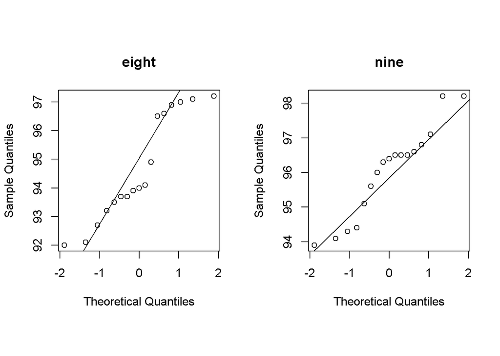

```r
eight<-STATTEMPS$temperature[STATTEMPS$class=="8 a.m."]
nine<-STATTEMPS$temperature[STATTEMPS$class=="9 a.m."]
par(mfrow=c(1,2),pty="s")
qqnorm(eight, main="eight")
qqline(eight)
qqnorm(nine, main="nine")
qqline(nine)
```

Como no sabemos si las varianzas son iguales o distintas, realizamos el cociente de varianzas

```r
var.test(x=eight, y=nine, conf.level = 0.95)$conf
```

```
## [1] 0.7188687 5.4814489
## attr(,"conf.level")
## [1] 0.95
```

Luego el cociente de varianzas está entre 0.7188687 y 5.4814489 con una confianza del 95%, al estar el uno incluido en el intervalo, podemos suponer que las varianzas son iguales

```r
t.test(x=eight, y=nine, var.equal=TRUE, conf.level = 0.95)$conf
```

```
## [1] -2.4917186 -0.2612226
## attr(,"conf.level")
## [1] 0.95
```

La diferencia de medias entre la temperaturas tomadas a las 8 am y a las 9 am está entre -2.4917186 y -0.2612226, al no estar incluido el cero concluimos con una confianza del 95% que la hora a la que se mide la temperatura es un parametro con cierta importancia

## Ejercicio 2

```r
library(PASWR2)
str(TOE)
```

```
## 'data.frame':    12 obs. of  1 variable:
##  $ energy: int  12222 6674 15961 3994 2841 1036 1343 4608 5864 17390 ...
```

```r
t.test(TOE , conf.level = 0.95)$conf
```

```
## [1]  3756.425 12788.075
## attr(,"conf.level")
## [1] 0.95
```

La media de cantidad de produccion de energía nuclear está entre 3756.425 y 12788.075 TOE con una confianza del 95%

## Ejercicio 3

## a)

```r
library(PASWR2)
str(FORMULA1)
```

```
## 'data.frame':    10 obs. of  3 variables:
##  $ race : int  1 2 3 4 5 6 7 8 9 10
##  $ team1: num  5.61 6.13 5.42 5.95 5.51 ...
##  $ team2: num  5.93 5.33 5.83 4.82 5.66 ...
```

```r
team1<-FORMULA1$team1
team2<-FORMULA1$team2
```

Realizamos el cociente de varianzas

```r
var.test(x=team1, y=team2, conf.level = 0.95)$conf
```

```
## [1] 0.1099935 1.7828442
## attr(,"conf.level")
## [1] 0.95
```

El cociente de varianzas está entre 0.1099935 y 1.7828442 con una confianza del 95%, al estar incluido el 1 asumimos que las varianzas son iguales

## b)

Calculamos la diferencia de medias entre los dos equipos en segundos

```r
t.test(x=team1, y=team2, var.equal=TRUE, conf.level = 0.95)$conf
```

```
## [1] -0.2420843  0.4636843
## attr(,"conf.level")
## [1] 0.95
```

La diferencia de medias poblacionales está entre -0.2420843 y 0.4636843 segundos con una confianza del 95%